# U3. La economía pre-clásica. Auge del comercio, el Estado-nación, y la transición a las ideas liberales

Historia del Pensamiento y del Análisis Económico

Sebastian Freille

Universidad Nacional de Córdoba

# Encuadre histórico y contextualización

## Metales, riqueza y comercio

> “The ordinary means therefore to increase our wealth and treasure is by Foreign Trade, wherein wee must ever observe this rule; to sell more to strangers yearly than wee consume of theirs in value” **[Thomas Mun (1630)**

> “This subject is an important and a complex one. Everyone knows what a difference it makes to the prosperity of the population in general and the prince in particular whether or not a state abounds in gold and silver. **[Antonio Serra (1613)]**

> “Foreign Trade is the only means to enrich this kingdom” **[Roger Coke (1670)]**

## Abordaje del mercantilismo

- Pocos temas en la historia del pensamiento económico dividen tanto las aguas como el mercantilismo.
- El mercantilismo puede ser definido y abordado como la coexistencia de tres cosas:
  - una colección dispersa de ideas y doctrinas teóricas,
  - un sistema de economía política y
  - un compendio de recetas y prácticas a modo de políticas económicas.
- Resulta importante entender las condiciones y el contexto que dan origen y sustento al mercantilismo y la temporalidad del mismo: entre los años 1500 y 1750 se suceden grandes cambios económicos, políticos y sociales.

## Un período de grandes cambios

- El periodo 1500-1750 puede considerarse como un largo período de transición entre la economía pre- y post-crecimiento. Hasta el siglo XVI, la economía era esencialmente un juego de suma cero sujeto a la denominada trampa Malthusiana.
- Los estándares de vida dependían del tamaño de la población y no de la tecnología. La clave era la cuenta neta de nacimientos y muertes: más nacimientos, menores ingresos y más muertes, mayores ingresos.
- En este contexto una conjunción de cambios institucionales, desarrollo de tecnologías e inventos y la caída del imperio bizantino configuró una situación inédita hasta ese momento: la posibilidad de aumentar el stock de bienes, factores y dinero a través de la exploración.

## Viajes y descubrimientos

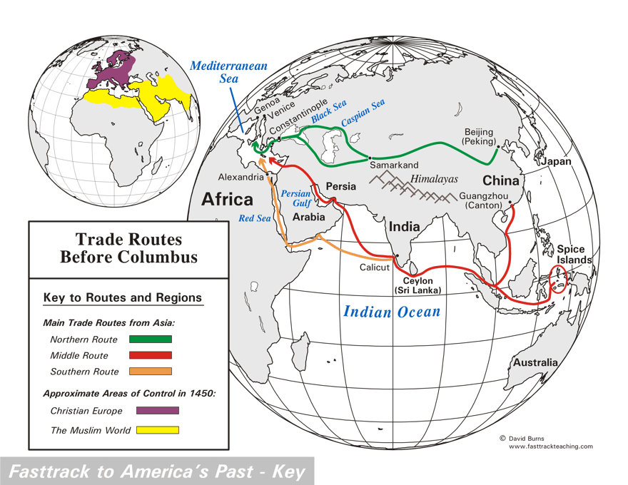

(a) Rutas comerciales

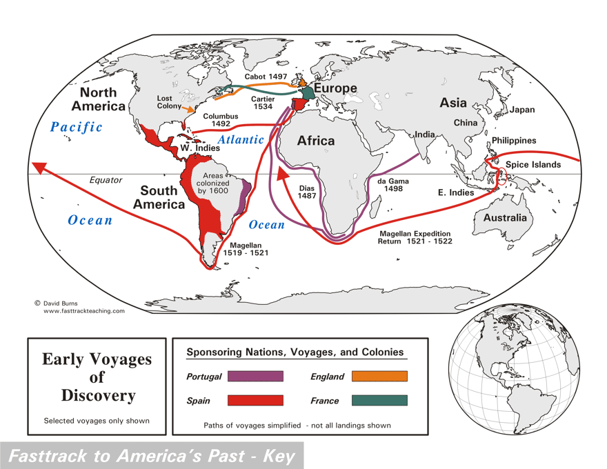

(b) Viajes de descubrimiento

Figura 1: Rutas, viajes y el nuevo mundo

## El crecimiento económico como fenómeno (cont.)

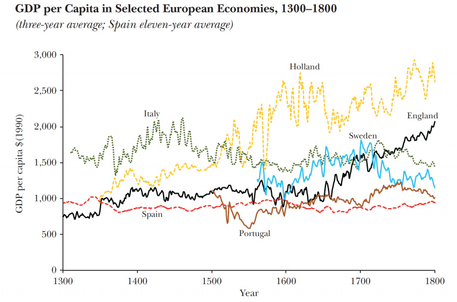

Figura 2: Crecimiento económico

## Dispersión conceptual, espacial y temporal

- El mercantilismo **no es considerada una escuela de pensamiento económico en el sentido estricto**: fue más bien una reacción intelectual en forma de ideas, visiones y políticas orientadas a preocupaciones (muchas y cambiantes) de la época
- Por ello resulta **difícil generalizar y sintetizar el pensamiento mercantilista**. No sólo por la heterogeneidad espacial y temporal sino porque los principales pensadores fueron comerciantes y no filósofos
- Asi y todo, el pensamiento mercantilista evolucionó en su calidad analítica particularmente entre 1650 y 1750. Esto nos permite aproximar las principales ideas, conceptos y discusiones teóricas y de política del mercantilismo así como también las diferentes tradiciones nacionales.

## Enfoques y abordaje

- Es pertinente una aclaración de método antes de describir las ideas y los acontecimientos. El mercantilismo puede ser abordado desde dos enfoques diferentes aunque complementarios
  - **Enfoque doctrinario** $\longrightarrow$ se lo estudia como un conjunto de ideas bastante cohesivo y estático. Presenta un conjunto de ideas y tendencias centrales que representaba el pensamiento y las creencias de la época.
  - **Enfoque político** $\longrightarrow$ se lo estudia como un sistema de economía política a partir de una dinámica de los intereses de un conjunto de actores en competencia y de las instituciones económicas y políticas establecidas a partir de esas interacciones.

# Principales temas

## Economía y política

- Se partía de un **supuesto clave: la riqueza total en el mundo era fija**. Así, la forma de aumentar la riqueza y el poder era a costa de otra nación.
- Por ello, promovieron el comercio internacional pero sobre todo la idea de **mantener una balanza comercial (BC) superavitaria** para aumentar la riqueza y prosperidad nacional.
- Para lograr el objetivo de mejorar la BC, debían fomentarse las exportaciones (X) y desincentivarse las importaciones (M). Así se **maximizaría la entrada de metales preciosos** (*bullion*)
- Y aquí entra la política por cuanto debía **usarse todo el poder del Estado-nación** para lograr esos objetivos: aranceles, cuotas, subvenciones, impuestos y regulaciones.

## Actividad, producción y consumo

- Salvo los primeros mercantilistas, se creía que el **objetivo de la actividad económica era la producción** y no el consumo
- La ecuación comprendía: 1) Aumentar la producciòn real (Y); 2) Aumentar las exportaciones (X); 3) Mantener bajo el consumo interno (C)
- La riqueza del Estado-nación se hacía a costa de una **población empobrecida**:
  - En el corto plazo, aumento de P de transables y disminución de C
  - En el largo plazo, aumento de P de transables/no transables y disminución de C
- Adicionalmente, estimulaban salarios básicos –*salarios de subsistencia*

## La balanza comercial

- Los mercantilistas pusieron en el centro de la escena la importancia monetaria y política del comercio internacional y con ello desarrollaron avances en registro y contabilidad de balanza comercial
- De hecho la idea actual de la balanza de pagos multilateral encuentra su fundamento y primeros indicios en la época mercantilista. Si bien no llegaron a comprender en su complejidad la vinculación de la balanza de pagos con la posición internacional de un país, la utilizaron como instrumento contable y analítico para lograr el objetivo último de maximizar la balanza comercial.
- Aquí también hubo diferencias entre el mercantilismo joven y tardío: el primero requería BC superavitaria con todos los países; el segundo una BC superavitaria global.

## Dinero y riqueza

- Tal vez la creencia más notable (y errónea) del mercantilismo joven era su **equiparación entre dinero y riqueza**.
- El **mercantilismo tardío, sin embargo, discutió y analizó el rol del dinero** en una economía, de hecho fue Jean Bodin quien citó varias causas del aumento de precios, la más importante para él, el aumento de la cantidad de oro y plata que siguió a los descubrimientos.
- Thomas Mun argumentaba que las X e M (y por ende la BC) dependían de los niveles de precios relativos en diferentes países.

## Dinero y riqueza (cont.)

> “It is not possible to increase the stock of one country by 20, 30 or 50 million without at the same time taking the same quantity from neighbouring states. Thus arises this two-fold increase, which has been so clearly discernible for several years past: on the one hand, the power and greatness of your Majesty increases, while on the other hand, that of your enemies and ill-wishers falls…I suppose that anyone would readily agree with this principle, namely, that is simply and solely the abundance of money within a state that makes the difference in its grandeur and power **[Jean Colbert (1670)]**

## Dinero y riqueza (cont.)

- El mercantilismo, al menos en sus primeras encarnaciones, consideraba que **la actividad económica y el crecimiento estaban determinados por factores monetarios**. Más *bullion*, mas crecimiento. En suma, creían que las variaciones en la cantidad de dinero ($M$) causaban variaciones en la producción real ($Y$) desconociendo tanto los determinantes de la producción real y los efectos sobre los precios ($P$).
- El **contraste con las ideas futuras de Adam Smith y la escuela clásica** no podía ser mayor: la actividad económica y el crecimiento estaban determinados por factores reales –cantidad de factores, tecnología y estructura institucional– y las variaciones en M sólo causaban aumentos en P, de esta manera adoptando las ideas de Bodin, Mun, Locke, Hume y Cantillon sobre la relación entre dinero y precios.

## Comercio exterior, metales y precios (cont.)

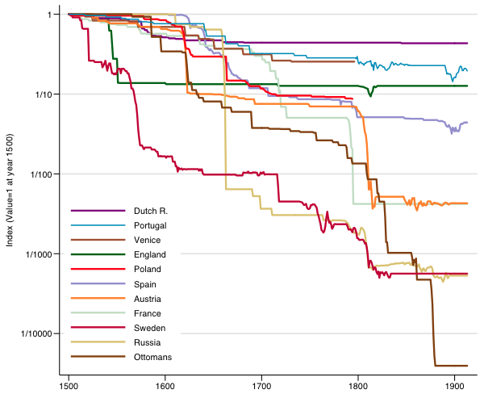

# Los aportes del mercantilismo

## Ideas que prenden

- En los últimos 100 años del período mercantilista, se empezaron a forjar las ideas que facilitaron la transición hacia la “economía científica”.
- Uno de los aportes fue reconocer que se podía analizar la economía relativizando el análisis moral y promoviendo análisis causa-efecto
- También se comprendió que el Estado no debería interferir excesivamente porque impactaría sobre la conducta e incentivos de los agentes
- Algunos aportes dejan entrever que reconocieron los errores analíticos del mercantilismo joven y abrazaron incipientemente ideas liberales
- No hubo, sin embargo, una teoría integrada del funcionamiento de los mercados y el sistema de precios.

## Mercantilismo tardío y transición liberal

- **Thomas Mun** fue un mercantilista *bona fide*: creía que la riqueza era fruto del comercio, abogaba por una BC+ y entrada de metales y a favor de la regulación pero criticó la idea de BC superavitaria con todas las naciones.
- **William Petty** fue el precursor de la medición económica a través de su método de la *aritmética política* (estadística). Fue un brillante y agudo pensador que inició una tradición metodológica que va desde el induccionismo empírico hasta la econometría de nuestros días
- **Bernard de Mandeville** sostuvo que el egoísmo era un vicio moral pero canalizado por el gobierno podía derivar en beneficios públicos. Proponía mucha población, trabajo infantil y salarios de pobreza ($O_{l}$ pendiente negativa)

## Mercantilismo tardío y transición liberal (cont.)

- **David Hume** fue una rara avis, un mercantilista liberal. Escribió sobre filosofía y política, y describió el mecanismo del precio-flujo de metales. De hecho, se diferenció tanto del mercantilismo joven como de la escuela clásica: el aumento gradual de $M$ podía aumentar la producción real al menos durante un cierto período de tiempo. Otra contribución fue su vinculación de las libertades económicas y libertades políticas
- Finalmente, **Richard Cantillon** fue una figura excepcional del pensamiento económico. Su libro es reconocido como el primer análisis sistemático de economía política. Concibió a la economía como un sistema de mercado que coordinaba a productores y consumidores a partir del interés personal. Analizó los ajustes del mercado ante diversos cambios. Entendió y amplió la TCD. Influyó en Quesnay y en los fisiócratas.

## Mercantilismo: reevaluación y actualidad

- El mercantilismo como cuerpo de ideas, doctrinas y políticas fue invisibilizado por la **devastadora crítica de la escuela clásica** y por el advenimiento de filosofía y condiciones más liberales. Sin embargo, hubo dos intentos fuertes por rescatarlo
- El primero fue de la escuela histórica alemana quienes defendieron al **mercantilismo como un sistema racional para lograr ciertos objetivos** en el contexto de su época
- El segundo, y más serio y contundente, fue el de Keynes. Keynes reconoció que las ideas y políticas de los mercantilistas tenían *fragmentos de sabiduría práctica*. Asimismo, valoró que detrás de la obsesión con las entradas de bullion había una “intuición de la conexión entre la abundancia de dinero y las bajas tasas de interés”.

## Mercantilismo: reevaluación y actualidad

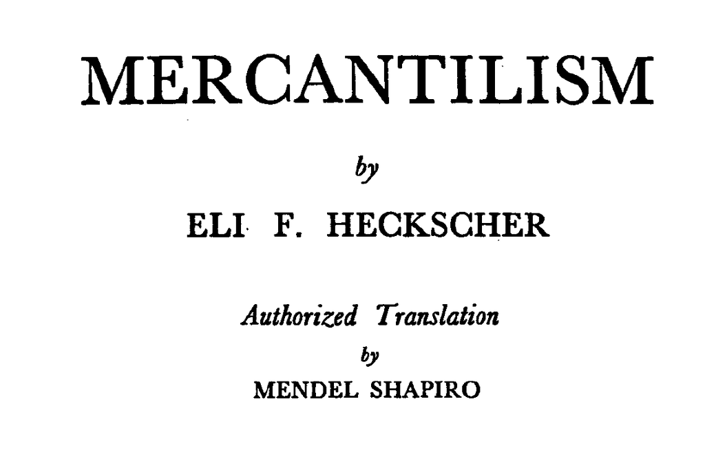

Figura 4

# Regulación y política económica

## El Estado y la búsqueda de rentas

- En cuanto a proceso y en su enfoque político, es usual considerar a los mercantilistas como puramente motivados por la **búsqueda de rentas**. Buscaban conseguir beneficios obteniendo privilegios por parte del gobierno. Uno de los principales privilegios era en forma de monopolios concedidos por el Estado.
- En la búsqueda de rentas intervienen distintos tipos de agentes con intereses diferentes. Algunos agentes, como los gobiernos proveen **oferta de regulación** y otros, como las empresas y comerciantes, constituyen la **demanda de regulación**.
- Se configura entonces una **relación de *quid-pro-quo*** en que las regulaciones y privilegios concedidos se otorgan a cambio de “votos” y dinero.

## El Estado y la búsqueda de rentas (cont.)

- El beneficio esperado para el comerciante y hombre de negocios derivaba de la concesión de monopolio (protección del Estado)
- El costo de organización era bajo en esa época por parte de los oferentes de regulación
- Esto generaba un conjunto de condiciones ideales para el florecimiento de actividad de búsqueda de rentas y actividad y políticas de regulación
- Es precisamente alrededor de esta época en que surgen los monopolios estatales. Particularmente importante fueron en los servicios de transporte marítimo de bienes, acuñación de moneda y banca y en la manufactura textil.

## El Estado y la búsqueda de rentas (cont.)

- Note que la prevalencia de estas condiciones y arreglos institucionales fue permitida por el hecho de que había una coalición con intereses mutuamente compatibles entre gobiernos y grupos de interés y pocos derechos y participación política de las masas ciudadanas
- Asimismo, es importante notar aspectos de la “organización industrial” de la actividad de búsqueda de rentas –si bien el mercantilismo centralizó fuertemente el poder y las políticas económicas, el control y el enforcement de las mismas debía muchas veces hacerse localmente
- Finalmente, es importante considerar las condiciones en que surge el mercantilismo como sistema de búsqueda de rentas, su auge y duración y su eventual reemplazo por otro sistema, instituciones y arreglos sustancialmente diferents.

## Especificidades nacionales

- Como dijimos anteriormente, las teorías, doctrinas y experiencias mercantilistas difirieron en el tiempo y en el espacio. Nos referimos antes a algunas diferencias en el tiempo y ahora haremos breve referencias a diferencias en el espacio.
- Hubo algunas experiencias de crecimiento muy importantes, Holanda e Inglaterra por mencionar algunas. Y también otros países que, aún sin mostrar experiencias similares, tuvieron variantes de mercantilismo particulares
- Nos referimos principalmente a Francia, España e Italia.

## Mercantilismo: Inglaterra

- El mercantilismo inglés fue enmarcado en un sistema político diferente al de otros países europeos: una monarquía constitucional en vez de absolutista. Esto implicaba que el poder sobre la política económica y la regulación estaba menos centralizado y promovió un tipo de relaciones coalicionales (y no de conflicto) entre grupos de interés y el Estado
- Una característica clave fue la implementación de regulación diferente de actividad local y nacional
  - Regulación de oficios: era local, basada en gremios medievales, y extremada con Ley de Trabajo isabelina y autoridad de Jueces de Paz
  - Regulación de industria: era nacional, creada por el Parlamento, el Rey y su corte.

## Mercantilismo: Inglaterra (cont.)

- Un aspecto clave era el control de las regulaciones: los Jueces de Paz frecuentemente fueron “capturados” por intereses económicos locales. Fueron el antecedente del burócrata moderno con flexibilidad para ofrecer acuerdos de corrupción
- Muchos artesanos, empresarios y hombres de negocios buscaron como eludir la regulación local: migración hacia campo. Se multiplican los mercados paralelos para esquivar regulacion y “bajar costos”
- El sistema de regulación local y su dificil control y la perdida de poder del monarca a manos del Parlamento hace que eventualmente desaparezca el icentivo a formar coaliciones y mantener el sistema de búsqueda de rentas.

## Mercantilismo: Francia

- El mercantilismo difería del inglés tanto en cuestiones políticas como económicas. En el inglés, eran las relaciones económicas de la sociedad civil las que garantizaban la estabilidad y prosperidad del Estado; en el francés, era el Estado el que garantizaba la unidad y armonía de la sociedad civil
- Una diferencia fue en los principales autores mercantilistas: en Inglaterra fueron comerciantes y hombres de negocios. En Francia fueron principalmente oficiales y funcionarios del régimen absolutista
- Por esta razón, fue difícil separar teoría y práctica en los escritos y acciones de figuras como Richelieu, Colbert y Montchretien.

## Mercantilismo: Francia (cont.)

- El mercantilismo francés identificaba al Estado como la principal categoría de análisis. Fusionaba los conceptos de economía y Estado. El principio básico era el logro de la autosuficiencia económica: esto se basaba en la alta inelasticidad de las exportaciones agrícolas francesas
- Y se proponía crear una industria a partir de sustituir importaciones
- También era importante el tema fiscal, impositivo de los privilegios regulatorios. A diferencia de Inglaterra, el paradigma absolutista francés implicó un persistente conflicto (a diferencia de coalición) entre los funcionarios y los grupos de interés. El ejemplo de las tirantes relaciones entre Colbert y varios grupos de interés fue tal vez el ejemplo mpas elocuente y vívido de las tensiones en el mercantilismo francés.